# Cyclist_report_finale

Irakli Ezugbaia

4/7/2022

## Business Task

In 2016, Cyclistic launched a successful bike-share offering. Since then, the program has grown to a fleet of 5,824 bicycles that are geotracked and locked into a network of 692 stations across Chicago. The bikes can be unlocked from one station and returned to any other station in the system anytime.

The marketing strategy is based on the flexibility of its pricing plans: single-ride passes, full-day passes, and annual memberships. Cyclistic’s finance analysts have concluded that annual members are much more profitable than casual riders.

The business task is to test a hypothesis that casual riders are ready made customers for annual plans. One of the questions for the marketing strategy is: how do annual members and casual riders use Cyclist bikes differently? Answers on this question may provide reasonable ground for recommending appropriate actions.

The stakeholders are: the marketing director, the company’s analytics team, and the executive board.

## Description of Data Sources

The data is generated from internal sources. It covers 12motnths of actual operations - January - December 2021. The data is organised in tables in cvs format.

The data seems of good quality, and is:

- reliable - as, reflects actual traffic numbers;
- original - as is generated from internal company sources;
- comprehensive - at certain level, as: a) the data does not reflect card numbers used for payments, b) The analysis would produce better results, if direct link with customers IDs or credit cards displayed, c) the data does not present pricing information to enable better evaluation of casual riders decisions from financial perspective;
- current - as, covers recent period by months;
- cited - as, is collected on internal sources.

## Documentation of Data Cleaning and Manipulaiton

R is used of data cleaning and manipulation in this analysis. Focus on:

- data type conventions;
- null values;
- duplicate records;
- data range validity;
- consistency of categorical value;
- missing data.

### Packages, libraries for packages

```r
library(tidyverse)
```

```r
library(maps)
library(lubridate)
library(dplyr)
library(scales)
library(sf)
```

### 12 months data imported into R:

```r
m_1 <- read_csv("/Users/ieremiafeodosii/Documents/Google data analytics certificate/Case-study_Cyclistic/data_csv/202101_td.csv")
m_2 <- read_csv("/Users/ieremiafeodosii/Documents/Google data analytics certificate/Case-study_Cyclistic/data_csv/202102_td.csv")
m_3 <- read_csv("/Users/ieremiafeodosii/Documents/Google data analytics certificate/Case-study_Cyclistic/data_csv/202103_td.csv")
m_4 <- read_csv("/Users/ieremiafeodosii/Documents/Google data analytics certificate/Case-study_Cyclistic/data_csv/202104_td.csv")
m_5 <- read_csv("/Users/ieremiafeodosii/Documents/Google data analytics certificate/Case-study_Cyclistic/data_csv/202105_td.csv")
m_6 <- read_csv("/Users/ieremiafeodosii/Documents/Google data analytics certificate/Case-study_Cyclistic/data_csv/202106_td.csv")
m_7 <- read_csv("/Users/ieremiafeodosii/Documents/Google data analytics certificate/Case-study_Cyclistic/data_csv/202107_td.csv")
m_8 <- read_csv("/Users/ieremiafeodosii/Documents/Google data analytics certificate/Case-study_Cyclistic/data_csv/202108_td.csv")
m_9 <- read_csv("/Users/ieremiafeodosii/Documents/Google data analytics certificate/Case-study_Cyclistic/data_csv/202109_td.csv")
m_10 <- read_csv("/Users/ieremiafeodosii/Documents/Google data analytics certificate/Case-study_Cyclistic/data_csv/202110_td.csv")
m_11 <- read_csv("/Users/ieremiafeodosii/Documents/Google data analytics certificate/Case-study_Cyclistic/data_csv/202111_td.csv")
m_12 <- read_csv("/Users/ieremiafeodosii/Documents/Google data analytics certificate/Case-study_Cyclistic/data_csv/202112_td.csv")
```

### The data frame:

- Bind into one data frame;
- View specs.

```r
m <- rbind(m_1, m_2, m_3, m_4, m_5, m_6, m_7, m_8, m_9, m_10, m_11, m_12)
glimpse(m)
```

```
## Rows: 5,595,063
## Columns: 13
## $ ride_id            <chr> "E19E6F1B8D4C42ED", "DC88F20C2C55F27F", "EC45C94683…
## $ rideable_type      <chr> "electric_bike", "electric_bike", "electric_bike", …
## $ started_at         <dttm> 2021-01-23 16:14:19, 2021-01-27 18:43:08, 2021-01-…
## $ ended_at           <dttm> 2021-01-23 16:24:44, 2021-01-27 18:47:12, 2021-01-…
## $ start_station_name <chr> "California Ave & Cortez St", "California Ave & Cor…
## $ start_station_id   <chr> "17660", "17660", "17660", "17660", "17660", "17660…
## $ end_station_name   <chr> NA, NA, NA, NA, NA, NA, NA, NA, NA, "Wood St & Augu…
## $ end_station_id     <chr> NA, NA, NA, NA, NA, NA, NA, NA, NA, "657", "13258",…
## $ start_lat          <dbl> 41.90034, 41.90033, 41.90031, 41.90040, 41.90033, 4…
## $ start_lng          <dbl> -87.69674, -87.69671, -87.69664, -87.69666, -87.696…
## $ end_lat            <dbl> 41.89000, 41.90000, 41.90000, 41.92000, 41.90000, 4…
## $ end_lng            <dbl> -87.72000, -87.69000, -87.70000, -87.69000, -87.700…
## $ member_casual      <chr> "member", "member", "member", "member", "casual", "…
```

### Data cleaning:

```r
m %>% distinct(ride_id)
```

```
## # A tibble: 5,595,063 × 1
##    ride_id
##    <chr>
##  1 E19E6F1B8D4C42ED
##  2 DC88F20C2C55F27F
##  3 EC45C94683FE3F27
##  4 4FA453A75AE377DB
##  5 BE5E8EB4E7263A0B
##  6 5D8969F88C773979
##  7 09275CC10F854E9E
##  8 DF7A32A217AEFB14
##  9 C2EFC62379EB716C
## 10 B9F73448DFBE0D45
## # … with 5,595,053 more rows
```

```r
glimpse(m)
```

```
## Rows: 5,595,063
## Columns: 13
## $ ride_id            <chr> "E19E6F1B8D4C42ED", "DC88F20C2C55F27F", "EC45C94683…
## $ rideable_type      <chr> "electric_bike", "electric_bike", "electric_bike", …
## $ started_at         <dttm> 2021-01-23 16:14:19, 2021-01-27 18:43:08, 2021-01-…
## $ ended_at           <dttm> 2021-01-23 16:24:44, 2021-01-27 18:47:12, 2021-01-…
## $ start_station_name <chr> "California Ave & Cortez St", "California Ave & Cor…
## $ start_station_id   <chr> "17660", "17660", "17660", "17660", "17660", "17660…
## $ end_station_name   <chr> NA, NA, NA, NA, NA, NA, NA, NA, NA, "Wood St & Augu…
## $ end_station_id     <chr> NA, NA, NA, NA, NA, NA, NA, NA, NA, "657", "13258",…
## $ start_lat          <dbl> 41.90034, 41.90033, 41.90031, 41.90040, 41.90033, 4…
## $ start_lng          <dbl> -87.69674, -87.69671, -87.69664, -87.69666, -87.696…
## $ end_lat            <dbl> 41.89000, 41.90000, 41.90000, 41.92000, 41.90000, 4…
## $ end_lng            <dbl> -87.72000, -87.69000, -87.70000, -87.69000, -87.700…
## $ member_casual      <chr> "member", "member", "member", "member", "casual", "…
```

```r
m %>% distinct(rideable_type)
```

```
## # A tibble: 3 × 1
##   rideable_type
##   <chr>
## 1 electric_bike
## 2 classic_bike
## 3 docked_bike
```

```r
m_01 <- m %>%
  drop_na()
glimpse(m_01)
```

```
## Rows: 4,588,302
## Columns: 13
## $ ride_id            <chr> "B9F73448DFBE0D45", "457C7F4B5D3DA135", "57C750326F…
## $ rideable_type      <chr> "classic_bike", "electric_bike", "electric_bike", "…
## $ started_at         <dttm> 2021-01-24 19:15:38, 2021-01-23 12:57:38, 2021-01-…
## $ ended_at           <dttm> 2021-01-24 19:22:51, 2021-01-23 13:02:10, 2021-01-…
## $ start_station_name <chr> "California Ave & Cortez St", "California Ave & Cor…
## $ start_station_id   <chr> "17660", "17660", "17660", "17660", "17660", "17660…
## $ end_station_name   <chr> "Wood St & Augusta Blvd", "California Ave & North A…
## $ end_station_id     <chr> "657", "13258", "657", "657", "657", "KA1504000135"…
## $ start_lat          <dbl> 41.90036, 41.90041, 41.90037, 41.90038, 41.90036, 4…
## $ start_lng          <dbl> -87.69670, -87.69673, -87.69669, -87.69672, -87.696…
## $ end_lat            <dbl> 41.89918, 41.91044, 41.89918, 41.89915, 41.89918, 4…
## $ end_lng            <dbl> -87.67220, -87.69689, -87.67218, -87.67218, -87.672…
## $ member_casual      <chr> "member", "member", "casual", "casual", "casual", "…
```

```r
m_02 <- m_01 %>%
  filter((started_at - ended_at) < 0)
glimpse(m_02)
```

```
## Rows: 4,588,104
## Columns: 13
## $ ride_id            <chr> "B9F73448DFBE0D45", "457C7F4B5D3DA135", "57C750326F…
## $ rideable_type      <chr> "classic_bike", "electric_bike", "electric_bike", "…
## $ started_at         <dttm> 2021-01-24 19:15:38, 2021-01-23 12:57:38, 2021-01-…
## $ ended_at           <dttm> 2021-01-24 19:22:51, 2021-01-23 13:02:10, 2021-01-…
## $ start_station_name <chr> "California Ave & Cortez St", "California Ave & Cor…
## $ start_station_id   <chr> "17660", "17660", "17660", "17660", "17660", "17660…
## $ end_station_name   <chr> "Wood St & Augusta Blvd", "California Ave & North A…
## $ end_station_id     <chr> "657", "13258", "657", "657", "657", "KA1504000135"…
## $ start_lat          <dbl> 41.90036, 41.90041, 41.90037, 41.90038, 41.90036, 4…
## $ start_lng          <dbl> -87.69670, -87.69673, -87.69669, -87.69672, -87.696…
## $ end_lat            <dbl> 41.89918, 41.91044, 41.89918, 41.89915, 41.89918, 4…
## $ end_lng            <dbl> -87.67220, -87.69689, -87.67218, -87.67218, -87.672…
## $ member_casual      <chr> "member", "member", "casual", "casual", "casual", "…
```

```r
m_02 %>% distinct(member_casual)
```

```
## # A tibble: 2 × 1
##   member_casual
##   <chr>
## 1 member
## 2 casual
```

```r
m_02 %>%
  distinct(start_station_name, start_station_id, start_lat, start_lng)
```

```
## # A tibble: 1,023,831 × 4
##    start_station_name         start_station_id start_lat start_lng
##    <chr>                      <chr>                <dbl>     <dbl>
##  1 California Ave & Cortez St 17660                 41.9     -87.7
##  2 California Ave & Cortez St 17660                 41.9     -87.7
##  3 California Ave & Cortez St 17660                 41.9     -87.7
##  4 California Ave & Cortez St 17660                 41.9     -87.7
##  5 California Ave & Cortez St 17660                 41.9     -87.7
##  6 California Ave & Cortez St 17660                 41.9     -87.7
##  7 California Ave & Cortez St 17660                 41.9     -87.7
##  8 California Ave & Cortez St 17660                 41.9     -87.7
##  9 California Ave & Cortez St 17660                 41.9     -87.7
## 10 California Ave & Cortez St 17660                 41.9     -87.7
## # … with 1,023,821 more rows
```

```r
m_02 %>%
  distinct(end_station_name, end_station_id, end_lat, end_lng)
```

```
## # A tibble: 980,416 × 4
##    end_station_name                end_station_id end_lat end_lng
##    <chr>                           <chr>            <dbl>   <dbl>
##  1 Wood St & Augusta Blvd          657               41.9   -87.7
##  2 California Ave & North Ave      13258             41.9   -87.7
##  3 Wood St & Augusta Blvd          657               41.9   -87.7
##  4 Wood St & Augusta Blvd          657               41.9   -87.7
##  5 Wells St & Elm St               KA1504000135      41.9   -87.6
##  6 Sacramento Blvd & Franklin Blvd KA1504000113      41.9   -87.7
##  7 Western Ave & Walton St         KA1504000103      41.9   -87.7
##  8 Damen Ave & Clybourn Ave        13271             41.9   -87.7
##  9 Damen Ave & Clybourn Ave        13271             41.9   -87.7
## 10 Leavitt St & North Ave          TA1308000005      41.9   -87.7
## # … with 980,406 more rows
```

### Additions to the data frame

- weekday column is added to the data frame;
- month column is added to the data frame;
- time column is added to the data frame;
- trip_duration column is added to the data frame.

```r
m_03 <- m_02 %>%
  mutate(month = month(started_at),
         hour = hms::as_hms(started_at))
glimpse(m_03)
```

```
## Rows: 4,588,104
## Columns: 15
## $ ride_id            <chr> "B9F73448DFBE0D45", "457C7F4B5D3DA135", "57C750326F…
## $ rideable_type      <chr> "classic_bike", "electric_bike", "electric_bike", "…
## $ started_at         <dttm> 2021-01-24 19:15:38, 2021-01-23 12:57:38, 2021-01-…
## $ ended_at           <dttm> 2021-01-24 19:22:51, 2021-01-23 13:02:10, 2021-01-…
## $ start_station_name <chr> "California Ave & Cortez St", "California Ave & Cor…
## $ start_station_id   <chr> "17660", "17660", "17660", "17660", "17660", "17660…
## $ end_station_name   <chr> "Wood St & Augusta Blvd", "California Ave & North A…
## $ end_station_id     <chr> "657", "13258", "657", "657", "657", "KA1504000135"…
## $ start_lat          <dbl> 41.90036, 41.90041, 41.90037, 41.90038, 41.90036, 4…
## $ start_lng          <dbl> -87.69670, -87.69673, -87.69669, -87.69672, -87.696…
## $ end_lat            <dbl> 41.89918, 41.91044, 41.89918, 41.89915, 41.89918, 4…
## $ end_lng            <dbl> -87.67220, -87.69689, -87.67218, -87.67218, -87.672…
## $ member_casual      <chr> "member", "member", "casual", "casual", "casual", "…
## $ month              <dbl> 1, 1, 1, 1, 1, 1, 1, 1, 1, 1, 1, 1, 1, 1, 1, 1, 1, …
## $ hour               <time> 19:15:38, 12:57:38, 15:28:04, 15:28:57, 15:56:59, …
```

```r
weekday <- wday(m_03$started_at, label = TRUE)
m_04 <- cbind(m_03, weekday)
glimpse(m_04)
```

```
## Rows: 4,588,104
## Columns: 16
## $ ride_id            <chr> "B9F73448DFBE0D45", "457C7F4B5D3DA135", "57C750326F…
## $ rideable_type      <chr> "classic_bike", "electric_bike", "electric_bike", "…
## $ started_at         <dttm> 2021-01-24 19:15:38, 2021-01-23 12:57:38, 2021-01-…
## $ ended_at           <dttm> 2021-01-24 19:22:51, 2021-01-23 13:02:10, 2021-01-…
## $ start_station_name <chr> "California Ave & Cortez St", "California Ave & Cor…
## $ start_station_id   <chr> "17660", "17660", "17660", "17660", "17660", "17660…
## $ end_station_name   <chr> "Wood St & Augusta Blvd", "California Ave & North A…
## $ end_station_id     <chr> "657", "13258", "657", "657", "657", "KA1504000135"…
## $ start_lat          <dbl> 41.90036, 41.90041, 41.90037, 41.90038, 41.90036, 4…
## $ start_lng          <dbl> -87.69670, -87.69673, -87.69669, -87.69672, -87.696…
## $ end_lat            <dbl> 41.89918, 41.91044, 41.89918, 41.89915, 41.89918, 4…
## $ end_lng            <dbl> -87.67220, -87.69689, -87.67218, -87.67218, -87.672…
## $ member_casual      <chr> "member", "member", "casual", "casual", "casual", "…
## $ month              <dbl> 1, 1, 1, 1, 1, 1, 1, 1, 1, 1, 1, 1, 1, 1, 1, 1, 1, …
## $ hour               <time> 19:15:38, 12:57:38, 15:28:04, 15:28:57, 15:56:59, …
## $ weekday            <ord> Sun, Sat, Sat, Sat, Sun, Fri, Tue, Sat, Wed, Fri, S…
```

```r
duration <- difftime(m_04$started_at, m_04$ended_at, units = "mins")
m_05 <- cbind(m_04, duration)
glimpse(m_05)
```

```
## Rows: 4,588,104
## Columns: 17
## $ ride_id            <chr> "B9F73448DFBE0D45", "457C7F4B5D3DA135", "57C750326F…
## $ rideable_type      <chr> "classic_bike", "electric_bike", "electric_bike", "…
## $ started_at         <dttm> 2021-01-24 19:15:38, 2021-01-23 12:57:38, 2021-01-…
## $ ended_at           <dttm> 2021-01-24 19:22:51, 2021-01-23 13:02:10, 2021-01-…
## $ start_station_name <chr> "California Ave & Cortez St", "California Ave & Cor…
## $ start_station_id   <chr> "17660", "17660", "17660", "17660", "17660", "17660…
## $ end_station_name   <chr> "Wood St & Augusta Blvd", "California Ave & North A…
## $ end_station_id     <chr> "657", "13258", "657", "657", "657", "KA1504000135"…
## $ start_lat          <dbl> 41.90036, 41.90041, 41.90037, 41.90038, 41.90036, 4…
## $ start_lng          <dbl> -87.69670, -87.69673, -87.69669, -87.69672, -87.696…
## $ end_lat            <dbl> 41.89918, 41.91044, 41.89918, 41.89915, 41.89918, 4…
## $ end_lng            <dbl> -87.67220, -87.69689, -87.67218, -87.67218, -87.672…
## $ member_casual      <chr> "member", "member", "casual", "casual", "casual", "…
## $ month              <dbl> 1, 1, 1, 1, 1, 1, 1, 1, 1, 1, 1, 1, 1, 1, 1, 1, 1, …
## $ hour               <time> 19:15:38, 12:57:38, 15:28:04, 15:28:57, 15:56:59, …
## $ weekday            <ord> Sun, Sat, Sat, Sat, Sun, Fri, Tue, Sat, Wed, Fri, S…
## $ duration           <drtn> -7.216667 mins, -4.533333 mins, -9.783333 mins, -8…
```

## Summary of Analysis

### Analysis:

#### trips_by_usertype:

- 2’048’302 casual and 2’539’802 member trips totaled in a 12months period.

```r
trips_by_usertype <- m_05 %>%
  select(member_casual) %>%
  group_by(member_casual) %>%
  count()
trips_by_usertype
```

```
## # A tibble: 2 × 2
## # Groups:   member_casual [2]
##   member_casual       n
##   <chr>           <int>
## 1 casual        2048302
## 2 member        2539802
```

#### trips_by_rideable_type

```r
trips_by_rideable_type <- m_05 %>%
  select(rideable_type) %>%
  group_by(m_05$rideable_type, m_05$member_casual) %>%
  count()
trips_by_rideable_type
```

```
## # A tibble: 6 × 3
## # Groups:   m_05$rideable_type, m_05$member_casual [6]
##   `m_05$rideable_type` `m_05$member_casual`       n
##   <chr>                <chr>                  <int>
## 1 classic_bike         casual               1261508
## 2 classic_bike         member               1980328
## 3 docked_bike          casual                312040
## 4 docked_bike          member                     1
## 5 electric_bike        casual                474754
## 6 electric_bike        member                559473
```

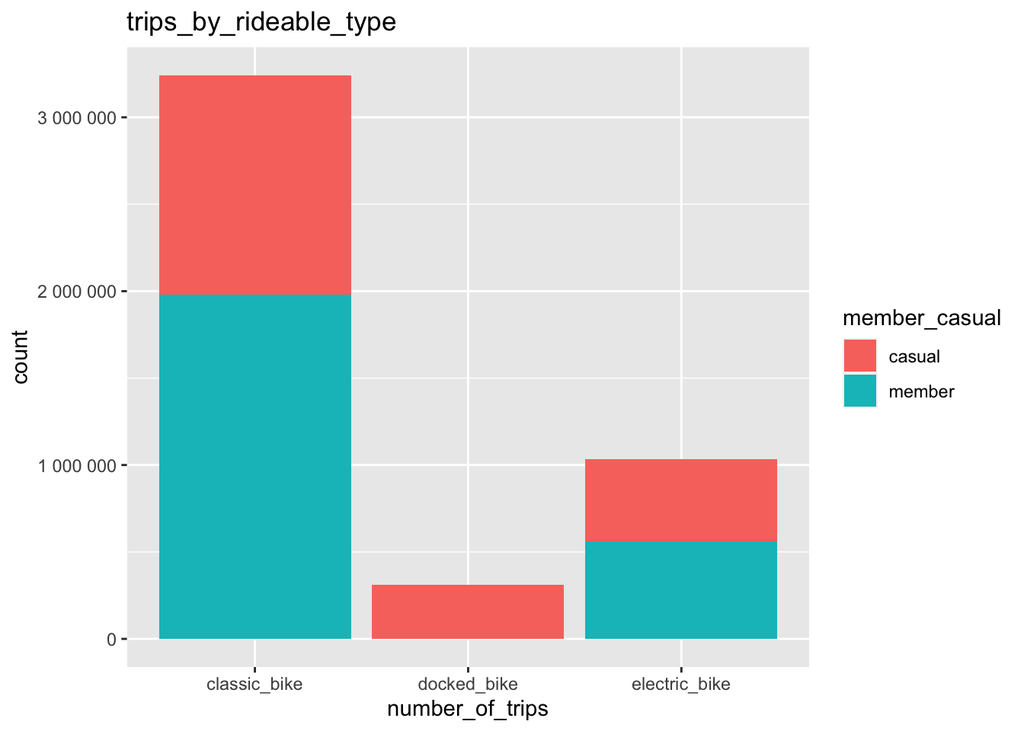

```r
ggplot(m_05, aes(rideable_type, grpup = member_casual, fill = member_casual)) +
  geom_bar() +
  labs(title = "trips_by_rideable_type", x = "number_of_trips") +
  scale_y_continuous(labels = number)
```

#### trips_by_weekdays:

```r
trips_by_weekdays <- m_05 %>%
  select(weekday) %>%
  group_by(m_05$weekday, m_05$member_casual) %>%
  count()
trips_by_weekdays
```

```
## # A tibble: 14 × 3
## # Groups:   m_05$weekday, m_05$member_casual [14]
##    `m_05$weekday` `m_05$member_casual`      n
##    <ord>          <chr>                 <int>
##  1 Sun            casual               403754
##  2 Sun            member               311212
##  3 Mon            casual               228931
##  4 Mon            member               346476
##  5 Tue            casual               214932
##  6 Tue            member               388120
##  7 Wed            casual               218129
##  8 Wed            member               397681
##  9 Thu            casual               224204
## 10 Thu            member               373469
## 11 Fri            casual               290034
## 12 Fri            member               365774
## 13 Sat            casual               468318
## 14 Sat            member               357070
```

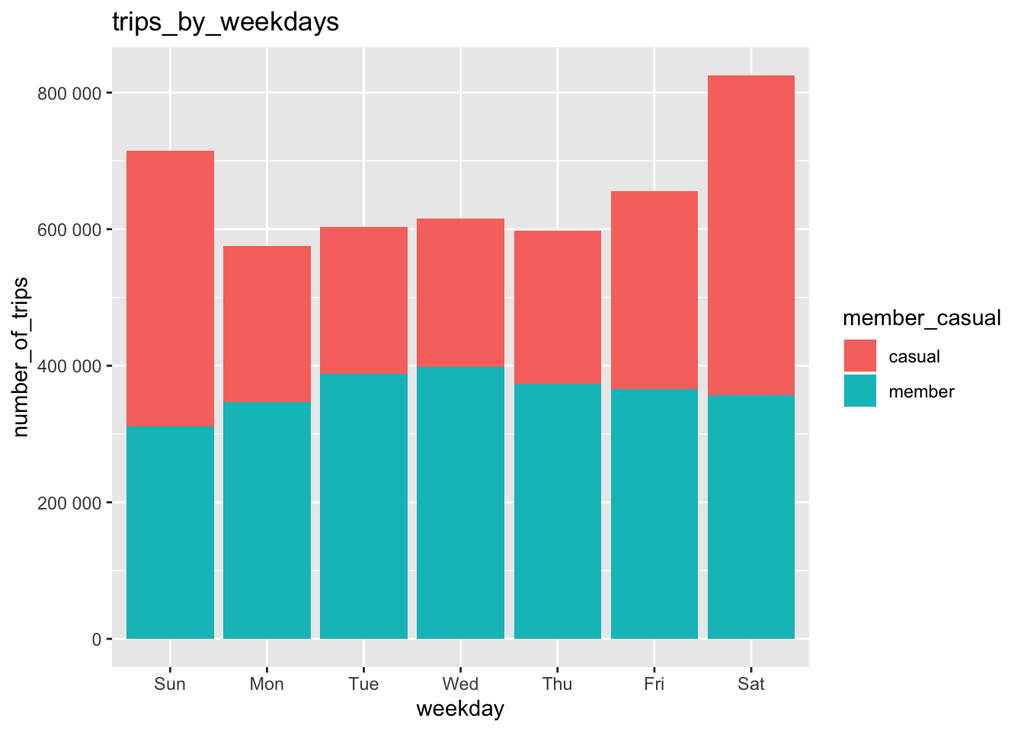

```r
ggplot(m_05, aes(weekday, group = member_casual, fill = member_casual)) +
  geom_bar() +
  labs(title = "trips_by_weekdays", y = "number_of_trips") +
  scale_y_continuous(labels = number)
```

#### trips_by_months:

```r
trips_by_months <- m_05 %>%
  select(month) %>%
  group_by(m_05$month, m_05$member_casual) %>%
  count()
trips_by_months
```

```
## # A tibble: 24 × 3
## # Groups:   m_05$month, m_05$member_casual [24]
##    `m_05$month` `m_05$member_casual`      n
##           <dbl> <chr>                 <int>
##  1            1 casual                14690
##  2            1 member                68818
##  3            2 casual                 8613
##  4            2 member                34381
##  5            3 casual                75641
##  6            3 member               130046
##  7            4 casual               120418
##  8            4 member               177781
##  9            5 casual               216823
## 10            5 member               234155
## # … with 14 more rows
```

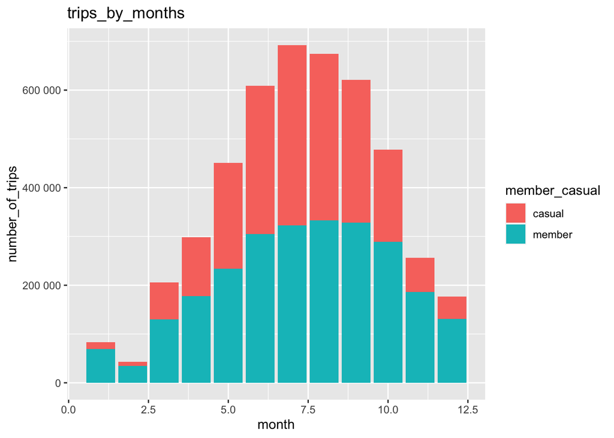

```r
ggplot(m_05, aes(month, group = member_casual, fill = member_casual)) +
  geom_bar() +
  labs(title = "trips_by_months", y = "number_of_trips") +
  scale_y_continuous(labels = number)
```

#### trips_by_hour:

```r
trips_by_hour <- m_05 %>%
  select(hour) %>%
  group_by(m_05$hour, m_05$member_casual) %>%
  count()
trips_by_hour
```

```
## # A tibble: 169,415 × 3
## # Groups:   m_05$hour, m_05$member_casual [169,415]
##    `m_05$hour` `m_05$member_casual`     n
##    <time>      <chr>                <int>
##  1 00'00"      casual                  14
##  2 00'00"      member                   9
##  3 00'01"      casual                   8
##  4 00'01"      member                  17
##  5 00'02"      casual                  19
##  6 00'02"      member                   7
##  7 00'03"      casual                  14
##  8 00'03"      member                  10
##  9 00'04"      casual                  20
## 10 00'04"      member                   7
## # … with 169,405 more rows
```

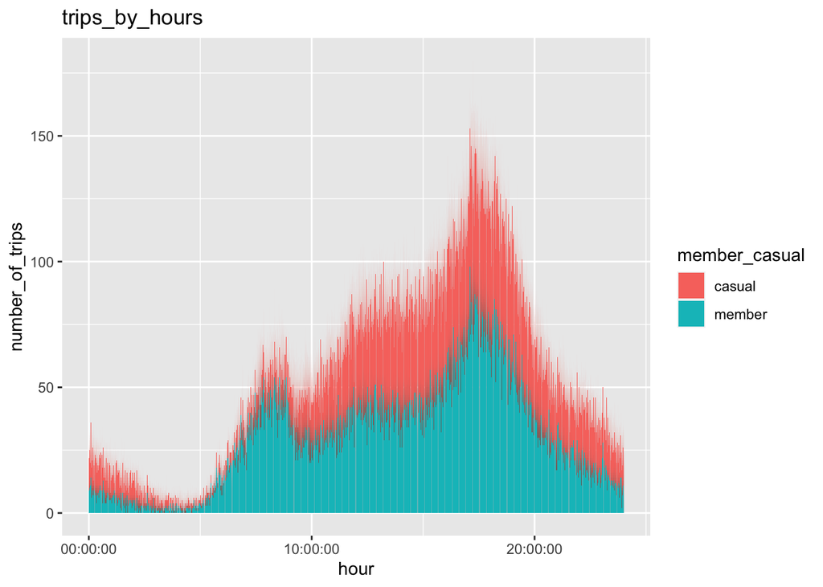

```r
ggplot(m_05, aes(hour, group = member_casual, fill = member_casual)) +
  geom_bar() +
  labs(title = "trips_by_hours", y = "number_of_trips")
```

#### trips_by_start_station:

```r
trips_by_station <- m_05 %>%
  select(start_station_name) %>%
  group_by(start_station_name, m_05$member_casual) %>%
  count()
trips_by_station
```

```
## # A tibble: 1,653 × 3
## # Groups:   start_station_name, m_05$member_casual [1,653]
##    start_station_name         `m_05$member_casual`     n
##    <chr>                      <chr>                <int>
##  1 2112 W Peterson Ave        casual                 341
##  2 2112 W Peterson Ave        member                 520
##  3 351                        casual                   1
##  4 63rd St Beach              casual                1414
##  5 63rd St Beach              member                 572
##  6 900 W Harrison St          casual                2487
##  7 900 W Harrison St          member                5637
##  8 Aberdeen St & Jackson Blvd casual                3463
##  9 Aberdeen St & Jackson Blvd member                8107
## 10 Aberdeen St & Monroe St    casual                3835
## # … with 1,643 more rows
```

[figure not shown]

```r
ggplot(m_05, aes(start_station_name, group = member_casual, fill = member_casual)) +
  geom_bar() +
  labs(title = "trips_by_start_station", y = "number_of_trips")
```

#### trips_by_start_site:

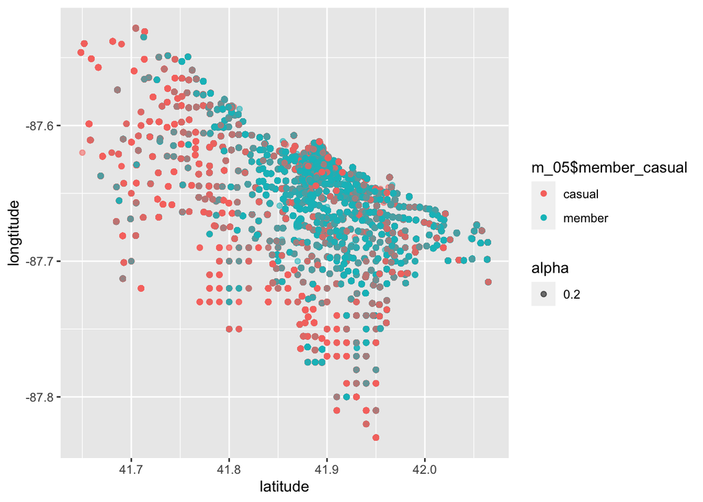

```r
start_sites <- data.frame(longtitude = c(m_05$start_lng), latitude = c(m_05$start_lat))

ggplot(start_sites, aes(latitude, longtitude, color = m_05$member_casual, alpha = 0.2)) +
  geom_point()
```

#### average_trip_duration:

```r
m_05 %>% group_by(member_casual) %>%
  summarise(mean = mean(duration))
```

```
## # A tibble: 2 × 2
##   member_casual mean
##   <chr>         <drtn>
## 1 casual        -32.51015 mins
## 2 member        -13.18401 mins
```

### Limitations and assumptions:

- no data re number of available bikes on stations at demand. Assumed full sypply;
- no access to payments data;
- no accesss to customer id data;
- The analysis ignores mistakes identified in data compilation. About 1mln distinct titles are identified for (start_station_name, start_station_id, start_lat, start_lng) and (end_station_name, end_station_id, end_lat, end_lng) combined entry. The sample size would decrease dramatically, if unique entries used, only. The stations data provided shall be corrected or a tolerated variance for lattitude and longtitude introduced for further analysis.

## Key Findings and Supporting Visualization

The business task of this analysis is to answer on a single question: how do annual members and casual riders use Cyclist bikes differently?

## Recommendaitons for a new promotion program, reorienting casual riders to members

An advertising campaign for casual members that aims to transfer them to members shall focus on:

- special offers for dock bikes;
- promotion for weekend trips;
- attention to non-business hours from 7pm to 1am;
- better offers for longer in time and distance trips.